# final_project_204589949_208848317

```python
from IPython.display import HTML

HTML('''<script>
code_show=true;
function code_toggle() {
if (code_show){
$('div.input').hide();
} else {
$('div.input').show();
}
code_show = !code_show
}
$( document ).ready(code_toggle);
</script>
<form action="javascript:code_toggle()"><input type="submit" value="Click here to toggle on/off the raw
code."></form>''')
```

*שאלה 1*

רקע לבחירות: הבחירות במדינת ישראל קורות לכל הפחות פעם ב4 שנים. בישראל, לרוב קורה שהבחירות מוקדמות ומתקיימות לפני המועד המקסימלי האפשרי. בשנת 2019 התקיימו בחירות בחודש אפריל בעקבות פיזור הכנסת. לאחר בחירות אלו אף מפלגה גדולה לא השכילה להקים ממשלה ולכן, בשל המחסור בהסכמה בין מפלגות מכריעות מסוימות, התקיימו בחירות נוספות בחודש ספטמבר של אותה השנה. אולם, גם בבחירות אלו, אל אף שינוים פנימיים ואיחודי מפלגות, לא הושגו ההסכמים הנדרשים להקמת ממשלה ולכן הוכרז, בפעם השלישית, על בחירות נוספות ב2020.

המפלגה שקיבלנו הינה מפלגת "שס" שמזוהה בעיקר עם הפלג החרדי מעדות המזרח במדינה וכראיה לכך, שמה המלא הינו "התאחדות הספרדים שומרי התורה תנועתו של מרן הרב עובדיה יוסף זצ"ל". מפלגה זו, לאורך השנים, מלווה בקהל בוחרים יחסית יציב וקבוע ותנודותיהם בין מערכות הבחירות השונות אינה גדולה.

לצורך העבודה נדרשנו לנתח קבצי נתונים שונים וכעת נפרט על קבצי נתונים אלו ותכולותיהם:

votes per ballot 2019a.csv, votes per ballot 2019b.csv, vote_per_kalpi_2020.csv: קבצי נתונים המכילים את נתוני הבחירות לפי הקלפיות במדינה בכל אחת ממערכות הבחירות. הקובץ הראשון מתייחס לבחירות הראשונות, שהתקיימו באפריל 2019, השני מתייחס לבחירות השניות באותה שנה שהתקיימו בספטמבר ואילו השלישי מתייחס לנתוני הבחירות של 2020.

בקבצים אלו ניתן למצוא את הקולות שכל מפלגה קיבלה בכל קלפי כאשר הקלפיות השונות נמצאות בשורות בטבלה ואילו המפלגות בעמודות הטבלה. בנוסף למפלגות השונות, קובץ הנתונים מכיל נתוני בחירות שונים עבור כל קלפי, כגון: בעלי זכות הבחירה, קולות פסולים, קולות כשרים, מספר קלפי, סמל יישוב וכ'ו.

העיבוד המקדים שעשינו לצורך שימוש יעיל ותכליתי בקבצי הנתונים סובב בעיקר סביב סידור ומיפוי נתונים רלוונטיים. עיבוד זה כלל הסרת עמודות או שורות שאינן רלוונטיות לניתוח (למשל, מעטפות חיצוניות וריכוז). בנוסף, מכל אחד מקבצי נתונים אלו יצרנו שתי דטאות שונות, אחת של המפלגות החזקות שעברו (או היו בעלות פוטנציאל רב לעבור) את אחוז החסימה (מספר שנע בין 8 ל10 מפלגות, לפי מערכת הבחירות) ואחת נוספת של מפלגות אלו בתוספת של נתונים מסווגים שיהוו כלי עזר לצורך איחוד ומיזוג דטאות בהמשך. כמו כן, ביצענו שינוי לשמות המפלגות הללו מסמל המפלגה הרשום על פתקי הבחירות לשמות המפלגות.

באופן דומה, ביצענו תהליך זהה עבור קבצי הנתונים המייצגים את מערכות הבחירות לפי ערים ולא לפי קלפיות, קבצי נתונים אלו הם:

votes per city 2019a.csv votes per city 2019b.csv votes per city 2020.csv

בנוסף, לצורך ניתוח מדויק יותר, הכולל מימד נוסף של אבחנה בין קהל הבוחרים השונה במדינה, נעזרנו בקובץ: Eshkol Hevrati Calcali.csv.

קובץ זה מכיל נתונים שונים אודות האשכול החברתי כלכלי של כל יישוב, לצד נתונים נלווים כמו מספר אנשים בישוב ועוד. בעמודה שימושית, בה בעיקר השתמשנו בניתוח זה, צוין רמת האשכול כלכל-חברתי של היישובים. כל ישוב מקבל מספר בין 1 ל10, כאשר 1 מיצג את הרמה הכלכלית חברתית הנמוכה ביותר עבור ישוב ו10 את הגבוהה ביותר במדינה.

נוסף על כך, צירפנו קובץ בשם "talmudiccolleges.csv"

מהאתר https://data.gov.il/dataset/talmudiccollege .

קובץ נתונים זה מכיל נתונים אודות כלל הישיבות התורניות בארץ לפי ערים. מקובץ נתונים זה נחלץ את העיר ומספר הפעמים שאותה העיר מופיעה בקובץ (כמות הישיבות בעיר זו) נמזג את דאטה זה עם קובץ הנתונים של האשכולות הכלכליים חברתיים.

בקובץ זה נשתמש לצורך זיהוי מוקדי כוח למפלגת שס תוך הנחה מוקדמת לפיה אחוז גדול יחסית מקהל המצביעים למפלגות בעלות אופי דתי כגון "שס", "יהדות התורה" ו"ימינה" יהוו מוקדים תורניים דתיים ומתוך כך גם מוקפים בישיבות.

```python
import numpy as np
import pandas as pd
import matplotlib.pyplot as plt
import io
import statsmodels.api as sm
from mpl_toolkits.mplot3d import Axes3D
from sklearn.decomposition import PCA
import copy
import seaborn as sns
from scipy.optimize import nnls
import scipy
from sklearn.preprocessing import normalize
```

```python
from google.colab import drive
drive.mount('/content/drive')

from google.colab import files
uploaded = files.upload()
```

Upload widget is only available when the cell has been executed in the current browser session. Please rerun this cell to enable.

```
Saving votes per city 2020.csv to votes per city 2020.csv
Saving votes per city 2019b.csv to votes per city 2019b.csv
Saving votes per city 2019a.csv to votes per city 2019a.csv
Saving votes per ballot 2020.csv to votes per ballot 2020.csv
Saving votes per ballot 2019b.csv to votes per ballot 2019b.csv
Saving votes per ballot 2019a.csv to votes per ballot 2019a.csv
Saving talmudiccolleges.csv to talmudiccolleges.csv
Saving Eshkol Hevrati Calcali.csv to Eshkol Hevrati Calcali.csv
```

```python
# uplouding data of election march 2020 by ballots
df_2020_kalpi_raw = pd.read_csv("votes per ballot 2020.csv", encoding = 'iso-8859-8', index_col='שם ישוב')
df_2020_kalpi_raw = df_2020_kalpi_raw.drop(index='מעטפות חיצוניות')
df_2020_kalpi_raw = df_2020_kalpi_raw.rename(columns = {'סמל ישוב': 'סמל ישוב', 'מחל': 'הליכוד', 'פה': 'כחול לבן', 'ודעם':'הרשימה המשותפת', 'שס':'שס', 'ג':'יהדות התורה', 'אמת':'עבודה מרץ גשר', 'ל':'ישראל ביתנו', 'טב':'ימינה', 'נץ': 'עוצמה יהודית'}, inplace = False)
ballot_2020 = df_2020_kalpi_raw[['סמל ישוב', 'קלפי', 'הליכוד', 'כחול לבן', 'הרשימה המשותפת', 'שס', 'יהדות התורה', 'עבודה מרץ גשר', 'ישראל ביתנו', 'ימינה', 'בזב', 'כשרים']]
ballot_2020_Otzma_Yehudit = df_2020_kalpi_raw[['סמל ישוב', 'קלפי', 'הליכוד', 'כחול לבן', 'הרשימה המשותפת', 'שס', 'יהדות התורה', 'עבודה מרץ גשר', 'ישראל ביתנו', 'ימינה', 'עוצמה יהודית', 'בזב', 'כשרים']]
ballot_2020_parties =  df_2020_kalpi_raw[['הליכוד', 'כחול לבן', 'הרשימה המשותפת', 'שס', 'יהדות התורה', 'עבודה מרץ גשר', 'ישראל ביתנו', 'ימינה']]
ballot_2020_parties_percent = ballot_2020_parties.div(ballot_2020_parties.sum(axis=1), axis=0)
```

```python
# uploud the data of the 2019 september elections by ballots
df_2019b_kalpi_raw = pd.read_csv("votes per ballot 2019b.csv", encoding = 'iso-8859-8', index_col='שם ישוב')
ballot_2019b = df_2019b_kalpi_raw.drop(index='מעטפות חיצוניות')
ballot_2019b = ballot_2019b.rename(columns = {'מחל': 'הליכוד', 'פה': 'כחול לבן', 'ודעם':'הרשימה המשותפת', 'שס':'שס', 'ג':'יהדות התורה', 'אמת':'עבודה גשר', 'ל':'ישראל ביתנו', 'טב':'ימינה', 'מרצ':'המחנה הדמוקרטי', 'כף':"עוצמה יהודית"}, inplace = False)
ballot_2019b = ballot_2019b[['סמל ישוב','קלפי','הליכוד', 'כחול לבן', 'הרשימה המשותפת', 'שס', 'יהדות התורה', 'עבודה גשר', 'ישראל ביתנו', 'ימינה', 'עוצמה יהודית', 'המחנה הדמוקרטי', 'בזב', 'כשרים']]
ballot_2019b_parties = ballot_2019b[['הליכוד', 'כחול לבן', 'הרשימה המשותפת', 'שס', 'יהדות התורה', 'עבודה גשר', 'ישראל ביתנו', 'ימינה', 'עוצמה יהודית', 'המחנה הדמוקרטי']]
ballot_2019b_parties_percent = ballot_2019b_parties.div(ballot_2019b_parties.sum(axis=1), axis=0)
```

```python
# uploud the data of the 2019 april elections by ballots
df_2019a_kalpi_raw = pd.read_csv("votes per ballot 2019a.csv", encoding = 'iso-8859-8', index_col='שם ישוב')
ballot_2019a = df_2019a_kalpi_raw.drop(index='מעטפות חיצוניות')
ballot_2019a = ballot_2019a.rename(columns = {'מחל': 'הליכוד', 'פה': 'כחול לבן', 'ום':'חד"ש-תע"ל', 'שס':'שס', 'ג':'יהדות התורה', 'אמת':'עבודה גשר', 'ל':'ישראל ביתנו', 'טב':'איחוד מפלגות הימין', 'מרצ':'המחנה הדמוקרטי', 'כ':'כולנו' ,'נץ':"עוצמה יהודית",  "דעם" : 'רע"מ-בל"ד'}, inplace = False)
ballot_2019a = ballot_2019a[['סמל ישוב','מספר קלפי','הליכוד', 'כחול לבן', 'שס', 'יהדות התורה', 'המחנה הדמוקרטי', 'עבודה גשר', 'ישראל ביתנו','חד"ש-תע"ל', 'רע"מ-בל"ד', 'איחוד מפלגות הימין', 'כולנו','כשרים', 'בזב']]
ballot_2019a_parties = ballot_2019a[['הליכוד', 'כחול לבן', 'שס', 'יהדות התורה', 'המחנה הדמוקרטי', 'עבודה גשר', 'ישראל ביתנו','חד"ש-תע"ל', 'רע"מ-בל"ד', 'איחוד מפלגות הימין', 'כולנו']]
ballot_2019a_parties_percent = ballot_2019a_parties.div(ballot_2019a_parties.sum(axis=1), axis=0)
```

```python
# uploud the data of the 2020 march elections by city
df_2020_city_raw = pd.read_csv("votes per city 2020.csv", encoding = 'iso-8859-8', index_col='שם ישוב')
df_2020_city = df_2020_city_raw.drop(index='מעטפות חיצוניות')
df_2020_city = df_2020_city.rename(columns = {'מחל': 'הליכוד', 'פה': 'כחול לבן', 'ודעם':'הרשימה המשותפת', 'שס':'שס', 'ג':'יהדות התורה', 'אמת':'עבודה מרץ גשר', 'ל':'ישראל ביתנו', 'טב':'ימינה'}, inplace = False)
df_2020_city = df_2020_city[['סמל ישוב' ,'הליכוד', 'כחול לבן', 'הרשימה המשותפת', 'שס', 'יהדות התורה', 'עבודה מרץ גשר', 'ישראל ביתנו', 'ימינה', 'בזב', 'כשרים']]
df_2020_city_partys = df_2020_city[['הליכוד', 'כחול לבן', 'הרשימה המשותפת', 'שס', 'יהדות התורה', 'עבודה מרץ גשר', 'ישראל ביתנו', 'ימינה']]
df_2020_city_partys_percent = df_2020_city_partys.div(df_2020_city_partys.sum(axis=1), axis=0)
```

```python
# uploud the data of the 2019 september elections by city
df_2019b_city_raw = pd.read_csv("votes per city 2019b.csv", encoding = 'iso-8859-8', index_col='שם ישוב')
df_2019b_city = df_2019b_city_raw.drop(index='מעטפות חיצוניות')
df_2019b_city = df_2019b_city.rename(columns = {'מחל': 'הליכוד', 'פה': 'כחול לבן', 'ודעם':'הרשימה המשותפת', 'שס':'שס', 'ג':'יהדות התורה', 'אמת':'עבודה גשר', 'ל':'ישראל ביתנו', 'טב':'ימינה', 'מרצ':'המחנה הדמוקרטי', 'כף':"עוצמה יהודית"}, inplace = False)
df_2019b_city = df_2019b_city[['סמל ישוב','הליכוד', 'כחול לבן', 'הרשימה המשותפת', 'שס', 'יהדות התורה', 'עבודה גשר', 'ישראל ביתנו', 'ימינה', 'עוצמה יהודית', 'המחנה הדמוקרטי', 'בזב', 'כשרים']]
df_2019b_city_partys = df_2019b_city[['הליכוד', 'כחול לבן', 'הרשימה המשותפת', 'שס', 'יהדות התורה', 'עבודה גשר', 'ישראל ביתנו', 'ימינה', 'עוצמה יהודית', 'המחנה הדמוקרטי']]
df_2019b_city_partys_percent = df_2019b_city_partys.div(df_2019b_city_partys.sum(axis=1), axis=0)
```

```python
# uploud the data of the 2019 april elections by city
df_2019a_city_raw = pd.read_csv("votes per city 2019a.csv", encoding = 'iso-8859-8', index_col='שם ישוב')
df_2020_city_raw = df_2019a_city_raw.drop(index='מעטפות חיצוניות')
df_2019a_city = df_2020_city_raw.rename(columns = {'מחל': 'הליכוד', 'פה': 'כחול לבן', 'ום':'חד"ש-תע"ל', 'שס':'שס', 'ג':'יהדות התורה', 'אמת':'עבודה גשר', 'ל':'ישראל ביתנו', 'טב':'איחוד מפלגות הימין', 'מרצ':'המחנה הדמוקרטי', 'כ':'כולנו' ,'נץ':"עוצמה יהודית",  "דעם" : 'רע"מ-בל"ד'}, inplace = False)
df_2019a_city = df_2019a_city[['סמל ישוב','הליכוד', 'כחול לבן', 'שס', 'יהדות התורה', 'המחנה הדמוקרטי', 'עבודה גשר', 'ישראל ביתנו','חד"ש-תע"ל', 'רע"מ-בל"ד', 'איחוד מפלגות הימין', 'כולנו', 'בזב']]
df_2019a_city_partys = df_2019a_city[['הליכוד', 'כחול לבן', 'שס', 'יהדות התורה', 'המחנה הדמוקרטי', 'עבודה גשר', 'ישראל ביתנו','חד"ש-תע"ל', 'רע"מ-בל"ד', 'איחוד מפלגות הימין', 'כולנו']]
df_2019a_city_partys_percent = df_2019a_city_partys.div(df_2019a_city_partys.sum(axis=1), axis=0)
```

```python
Eshkol_Calcali = pd.read_csv(('Eshkol Hevrati Calcali.csv'), encoding='utf_8')
```

```python
talmudiccolleges = pd.read_csv("talmudiccolleges.csv", encoding = 'iso-8859-8')
city_list = talmudiccolleges['SETL_CODE'].unique()
talmudi = pd.DataFrame([city_list, [len(talmudiccolleges.loc[talmudiccolleges['SETL_CODE']==city_code]) for city_code in city_list]]).T
talmudi.columns = ['set_code', 'מספר ישיבות']
```

# **שאלה ב**

```
The vote percentage for 'שס' in each election, was:  in April 2019 0.06643 in September 2019 0.07592 in 2020 0.07793
```

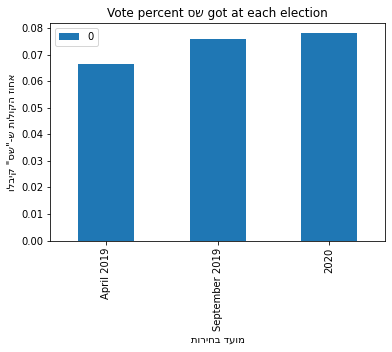

```python
# Get votes of all parties (normalized)
def parties_votes(df, thresh):
    par = round(df.sum().div(df.sum().sum()).sort_values(ascending=False),5)
    return par[par > thresh]

part_percent_2020 = parties_votes(ballot_2020_parties, 0.0325)
part_percent_2019b = parties_votes(ballot_2019b_parties, 0.0325)
part_percent_2019a = parties_votes(ballot_2019a_parties, 0.0325)

shas_percent = pd.DataFrame([part_percent_2019a['שס'],part_percent_2019b['שס'],part_percent_2020['שס']])
shas_percent.index = ['April 2019', "September 2019", "2020"]
shas_percent.plot(kind='bar')
plt.title("Vote percent סש got at each election")
plt.xlabel('מועד בחירות'[::-1])
plt.ylabel('אחוז הקולות ש-"שס" קיבלו'[::-1])
print("The vote percentage for 'שס' in each election, was:  in April 2019", part_percent_2019a['שס'], "in September 2019", part_percent_2019b['שס'], "in 2020", part_percent_2020['שס'])
```

ניתן לראות שאחוז ההצבעה למפלגת 'שס' נותר יחסית דומה בשלושת מערכות הבחירות הללו, אמנם ניכרת עליה קלה בין מערכות הבחירות השונות של 2019 אך אחוזי ההצבעה (המתורגמים למנדטים) לא משתנים בצורה חדה. התוצאה מעליה קלה זו תורגמה בסה"כ למנדט אחד נוסף עבור המפלגה. הסיבה לכך היא קהל הבוחרים היציב של המפלגה, המפלגה פונה בעיקר לקהל חרדי ספרדי וקהל זה בוחר במפלגה בכל מערכת בחירות ומהווה יציבות מתמשכת בבחירות לאורך השנים. אמנם שינוים קלים כן עשויים לקרות, בעיקר בשל מעברים בין מפלגות, על כך נרחיב בהמשך.

# **שאלה ג**

Fixing the data to 100% votes:

Vi = kosher(i) / bzb(i)

```python
v_2020 = ballot_2020['כשרים'].div(ballot_2020['בזב'])
ballot_2020_parties_fix = ballot_2020_parties.div(v_2020 , axis = 'rows')
part_percent_2020_fix = parties_votes(ballot_2020_parties_fix, 0.0325)
print("If everyone voted in 2020 elections then 'שס' would have gotten ", part_percent_2020_fix['שס'], "percent, meaning that their vote percentage would decrease in ", round(part_percent_2020['שס'] - part_percent_2020_fix['שס'],4), "percent.")
```

```
If everyone voted in 2020 elections then 'שס' would have gotten  0.07642 percent, meaning that their vote percentage would decrease in  0.0015 percent.
```

```python
v_2019b = ballot_2019b['כשרים'].div(ballot_2019b['בזב'])
ballot_2019b_parties_fix = ballot_2019b_parties.div(v_2019b , axis = 'rows')
part_percent_2019b_fix = parties_votes(ballot_2019b_parties_fix, 0.0325)
part_percent_2019b_fix
print("If everyone voted in September 2019 elections then 'שס' would have gotten ", part_percent_2019b_fix['שס'],"percent, meaning that their vote percentage would decrease in " , round(part_percent_2019b['שס'] - part_percent_2019b_fix['שס'],4), "percent.")
```

```
If everyone voted in September 2019 elections then 'שס' would have gotten  0.07384 percent, meaning that their vote percentage would decrease in  0.0021 percent.
```

ניתן לשים לב לירידה הקלה שחלה באחוזי ההצבעה עבור המפלגה, זאת משום שאחוזי ההצבעה בקרב תומכי מפלגת שס קרובים יחסית לאחוז ההצבעה הכללי במדינה מלכתחילה ואף מעט גבוהים מאחוז ההצבעה הכללי. לכן, אם יותר אנשים יצביעו, סביר שיצביעו יותר למפלגות אחרות מאשר לשס ולכן צפויה לשס ירידה קלה עבור תיקון זה. יחד עם זאת, נשים לב שלא מדובר בירידה דרסטית, כלומר, גם עבור התיקון שס צפויים לקבל בקירוב את מספר הצפוי להם. לכן, נמליץ לראש המפלגה להיות אדיש כלפי אחוז ההצבעה הכללי ולא להשקיע משאבים נוספים כדי לשכנע את כלל האוכלוסייה לצאת ולהצביע. לעומת זאת, יתכן וקיימים מוקדי כח ספציפיים בהם כן נמליץ לראש המפלגה להשקיע משאבים בניסיון לשכנע קהלים ספציפיים לצאת ולהצביע, על כך נרחיב בסעיף הבא.

# **שאלה ד**

לעומת זאת, בבחירות 2020 בעיר חיפה, מפלגת שס קיבלה את אחוז ההצבעות הנמוך ביותר מבין המפלגות שעברו את אחוז החסימה (2.92%). מדובר באחוז הצבעה נמוך מאוד ביחס למפלגה זו ולאור העובדה שבחיפה יש מספר גדול של בעלי זכות בחירה מדובר במוקד חולשה של שס. בעיר זו, כיועצים לראש המפלגה, היינו מעדיפים שאחוז ההצבעה יהיה נמוך ככל האפשר וכך מפלגות מתחרות יאבדו מכוחם.

ביחס לאשכול כלכלי

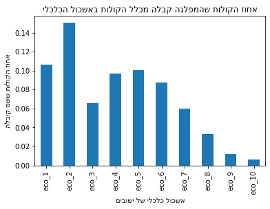

```python
df_2020_city['שם ישוב'] = df_2020_city.index
df_2020_city_calcali =  pd.merge(left=df_2020_city, right=Eshkol_Calcali[['population','eco_level','set_code']], left_on='סמל ישוב', right_on='set_code')
df_2020_city_calcali.set_index('שם ישוב', inplace=True)
df_2020_city_calcali = df_2020_city_calcali[[ 'הליכוד', 'כחול לבן', 'הרשימה המשותפת', 'שס', 'יהדות התורה', 'עבודה מרץ גשר', 'ישראל ביתנו', 'ימינה', 'eco_level']]
df_2020_city_calcali_partys = df_2020_city_calcali[[ 'הליכוד', 'כחול לבן', 'הרשימה המשותפת', 'שס', 'יהדות התורה', 'עבודה מרץ גשר', 'ישראל ביתנו', 'ימינה']]

all_shas_votes = df_2020_city_calcali['שס'].sum()
shas_eco_percents = pd.DataFrame(columns=['eco_'+str(a) for a in range(1,11)], index=['percent from eco_level voters', 'percent from shas voters'])
for level in range(0,10):
    level_citys = df_2020_city_calcali_partys[df_2020_city_calcali.eco_level == level+1]
    level_sum = level_citys.sum().sum()
    shas_sum = level_citys['שס'].sum()
    shas_eco_percents.iloc[0,level] = shas_sum/level_sum
    shas_eco_percents.iloc[1,level] = shas_sum/all_shas_votes

shas_eco_percents
shas_eco_percents.loc['percent from eco_level voters'].plot(kind = "bar")
plt.title("אחוז הקולות שהמפלגה קבלה מכלל הקולות באשכול הכלכלי"[::-1])
plt.xlabel("אשכול כלכלי של ישובים"[::-1])
plt.ylabel("אחוז הקולות ששס קיבלה"[::-1])
```

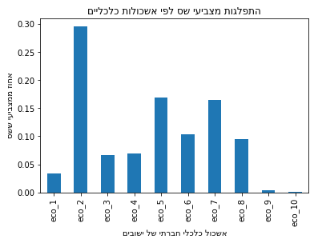

```python
a = pd.DataFrame(df_2020_city['שס'].multiply(df_2020_city['שס'].div(df_2020_city['כשרים']))).sort_values(0, ascending=False)
a[0:20]
shas_eco_percents.loc['percent from shas voters'].plot(kind = "bar")
plt.title("התפלגות מצביעי שס לפי אשכולות כלכליים"[::-1])
plt.xlabel("אשכול כלכלי חברתי של ישובים"[::-1])
plt.ylabel("אחוז ממצביעי ששס"[::-1])
```

נשים לב כי שס חזקה באופן יחסי באשכול כלכלי חברתי 2. נשים לב שמוקדי כוח חזקים מאוד עבור מפלגה זו הם ערים כמו בני ברק, ירושלים ובית שמש אשר מוכלים באשכול זה.

ביחס לבחירות קודמות

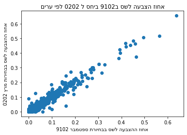

```python
shas_city_2019b_2020 = pd.merge(df_2020_city_partys_percent['שס'], right=df_2019b_city_partys_percent['שס'], left_on='שם ישוב', right_on='שם ישוב', suffixes=('_2020', '_2019_september'))
plt.scatter(shas_city_2019b_2020['שס_2019_september'],shas_city_2019b_2020['שס_2020'])

plt.title("אחוז הצבעה לשס ב2019 ביחס ל 2020 לפי ערים"[::-1])
plt.xlabel("אחוז ההצבעה לשס בבחיורת ספטמבר 2019"[::-1])
plt.ylabel("אחוז ההצבעה לשס בבחירות מרץ 2020"[::-1])
```

ניתן להחבין בקונסיסטנטיות של שס בשתי מערכות הבחירות הללו. מוקדי ההצבעה (לפי ערים) נותרו דומים מאוד ולכן בבואנו לבחון אחוזי הצבעה עתידיים עבור מפלגה זו, היינו ממליצים לראש המפלגה לבחון נתוני בחירות קודמות ולהסיק מוקדי כוח מתוכן.

לפי מספר ישיבות

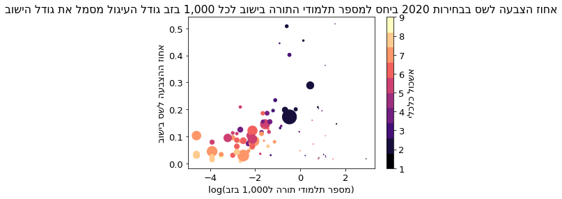

```python
city_partys_percent_2020 = df_2020_city_partys_percent
city_partys_percent_2020['set_code'] = df_2020_city_raw['סמל ישוב']
city_partys_percent_2020['בזב'] = df_2020_city_raw['בזב']
talmudi_party_percent = city_partys_percent_2020.set_index('set_code').join(talmudi.set_index('set_code'), how = 'inner').fillna(0)

talmudi_party_percent['מספר ישיבות ל1000 תושבים'] = round(talmudi_party_percent['מספר ישיבות'].div(talmudi_party_percent['בזב'], axis = 0)*1000, 2)
talmudi_party_percent['log מספר ישיבות ל1000 תושבים'] = np.log((talmudi_party_percent['מספר ישיבות ל1000 תושבים']))
talmudi_party_percent = talmudi_party_percent.join(Eshkol_Calcali.set_index('set_code'), how = 'inner')

cmap = plt.cm.get_cmap("magma", 10)
plot = plt.scatter(talmudi_party_percent['log מספר ישיבות ל1000 תושבים'],talmudi_party_percent['שס'], c = talmudi_party_percent['eco_level'], s = talmudi_party_percent['בזב']*0.001, cmap=cmap)
plt.title("אחוז הצבעה לשס בבחירות 0202 ביחס למספר תלמודי התורה בישוב לכל 000,1 בזב גודל העיגול מסמל את גודל הישוב"[::-1])
plt.xlabel(")מספר תלמודי תורה ל000,1 בזב(gol"[::-1])
plt.ylabel("אחוז ההצבעה לשס בישוב"[::-1])
clb = plt.colorbar(plot)
clb.set_label('אשכול כלכלי'[::-1])
# pws = [100, 1000, 10000, 100000, 1000000]
# for pw in pws:
#     plt.scatter([], [], s=(pw**2)*60, c="k",label=str(pw))
```

שאלה ה חלק א

2020

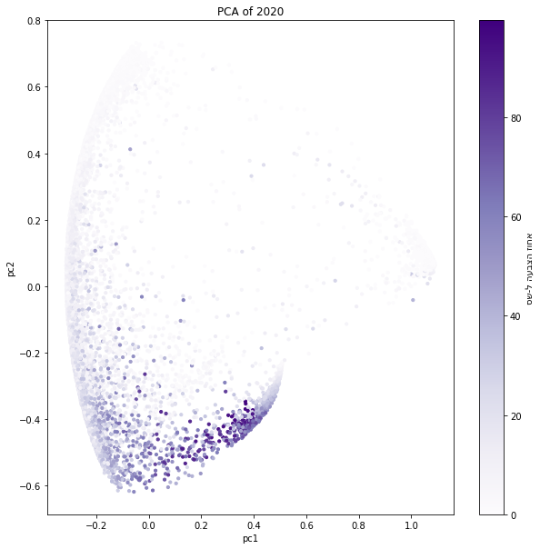

```python
pca_2020 = df_2020_kalpi_raw.iloc[:,10:40]
ballot_2020_parties_norm_percent= pca_2020.div(np.sqrt(np.sum((pca_2020.T)*(pca_2020.T), axis=0)), axis=0)
pca = PCA(n_components=2)
ballot_2020_parties_percent_pca = pca.fit_transform(ballot_2020_parties_norm_percent)
y = ballot_2020_parties_percent_pca[:,1]
x = ballot_2020_parties_percent_pca[:,0]

fig, ax = plt.subplots(figsize = (10, 10))
plot = ax.scatter(x ,y , c=100*ballot_2020_parties_norm_percent['שס'], s=10, label='2020', cmap="Purples")
plt.ylabel('pc2')
clb = plt.colorbar(plot)
clb.set_label('אחוז הצבעה ל-שס'[::-1])
plt.xlabel('pc1')
ax.set_title("PCA of 2020")
plt.show()
```

2019b

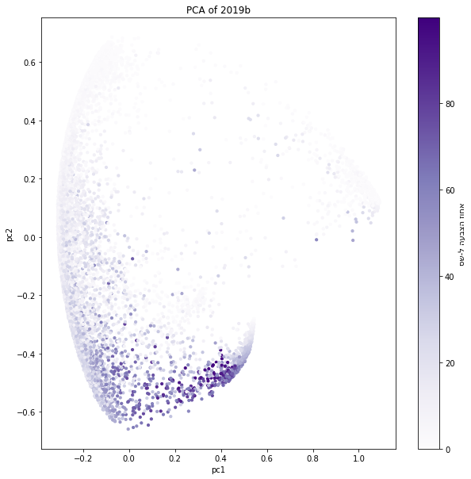

```python
pca_2019b = df_2019b_kalpi_raw.iloc[:,10:42]
ballot_2019b_parties_norm_percent= pca_2019b.div(np.sqrt(np.sum((pca_2019b.T)*(pca_2019b.T), axis=0)), axis=0).fillna(0)
pca = PCA(n_components=2)
ballot_2019b_parties_percent_pca = pca.fit_transform(ballot_2019b_parties_norm_percent)
y = ballot_2019b_parties_percent_pca[:,1]
x = ballot_2019b_parties_percent_pca[:,0]

fig, ax = plt.subplots(figsize = (10, 10))
plot = ax.scatter(x ,y , c=100*ballot_2019b_parties_norm_percent['שס'], s=10, label='2019b', cmap="Purples")
plt.ylabel('pc2')
plt.xlabel('pc1')
clb = plt.colorbar(plot)
clb.set_label('אחוז הצבעה ל-שס'[::-1])
ax.set_title("PCA of 2019b")
plt.show()
```

2019 a

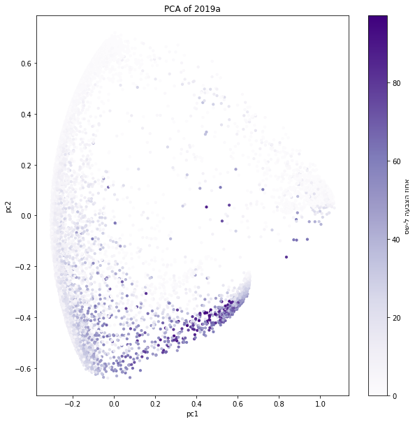

```python
pca_2019a = df_2019a_kalpi_raw.iloc[:,6:49]
ballot_2019a_parties_norm_percent= pca_2019a.div(np.sqrt(np.sum((pca_2019a.T)*(pca_2019a.T), axis=0)), axis=0).fillna(0)
pca = PCA(n_components=2)
ballot_2019a_parties_percent_pca = pca.fit_transform(ballot_2019a_parties_norm_percent)
y = ballot_2019a_parties_percent_pca[:,1]
x = ballot_2019a_parties_percent_pca[:,0]

fig, ax = plt.subplots(figsize = (10, 10))
plot = ax.scatter(x ,y , c=100*ballot_2019a_parties_norm_percent['שס'], s=10, label='2019a', cmap="Purples")
plt.ylabel('pc2')
plt.xlabel('pc1')
clb = plt.colorbar(plot)
clb.set_label('אחוז הצבעה ל-שס'[::-1])
ax.set_title("PCA of 2019a")
plt.show()
```

הגרפים מראים תמונה של וקטורי הקלפיות במישור הנפרש ע"י 2 וקטורי ה-PC הראשונים כאשר הצבע מתאר את אחוז ההצבעה למפלגת שס בכל אחת משלושת מערכות הבחירות. בPCA אנו נראה התקבצות של קלפיות בעלות אופי דומה באחוזי ההצבעה שלהן למפלגות השונות נמצאות באותם איזורים בגרף. נשים לב לאיזורים הצבועים בגרפים השונים, המתארים את הקלפיות השונות שנוטות לבחור בשס יותר. נבחין כי שס נוטה לקבל יחסית הרבה קולות מיחסית מעט קלפיות.

בתהליך זה אנו מורידים מימדים מסוימים מתוך מחשבה שמימדים אלו חשובים פחות בכל הנוגע להסבר על השונות של הדאטה. מדובר למעשה ב-trade-off בין רמת תצוגה בהירה של הנתונים לבין דיוק הנתונים המוסברת.

שאלה ה חלק ב

2020-2019b

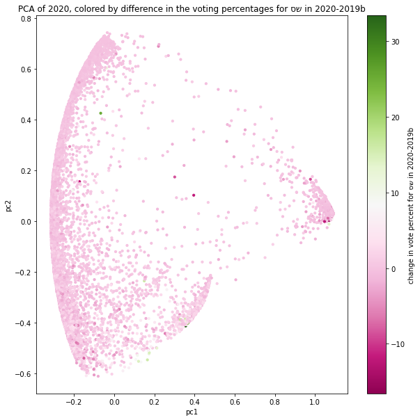

```python
df_2019b_kalpi_raw['שם ישוב'] = df_2019b_kalpi_raw.index
ballot_2019b_2020 = pd.merge(left=df_2019b_kalpi_raw, right=df_2020_kalpi_raw, how='inner', left_on=['סמל ישוב','קלפי'], right_on=['סמל ישוב','קלפי'], suffixes=(' 2019b', ' 2020'))
ballot_2019b_2020.index = ballot_2019b_2020['שם ישוב']

ballot_2019b_clean = ballot_2019b_2020.iloc[:,10:42]
ballot_2020_clean = ballot_2019b_2020.iloc[:,51:81]
ballot_2019b_2020['vote_percent_2020'] = ballot_2020_clean.sum(axis=1).div(ballot_2019b_2020['בזב 2020'], axis=0)
ballot_2019b_2020['vote_percent_shas_2020'] = ballot_2019b_2020['שס 2020'].div(ballot_2019b_2020['כשרים 2020'], axis=0)
ballot_2019b_2020['vote_percent_shas_2019b'] = ballot_2019b_2020['שס 2019b'].div(ballot_2019b_2020['כשרים 2019b'], axis=0)
ballot_2019b_2020['vote_percent_shas_2020-2019b'] = ballot_2019b_2020['vote_percent_shas_2020'] - ballot_2019b_2020['vote_percent_shas_2019b']

pca_2020 = ballot_2020_clean
ballot_2020_parties_norm_percent= pca_2020.div(np.sqrt(np.sum((pca_2020.T)*(pca_2020.T), axis=0)), axis=0)
pca = PCA(n_components=2)
ballot_2020_parties_percent_pca = pca.fit_transform(ballot_2020_parties_norm_percent)
y = ballot_2020_parties_percent_pca[:,1]
x = ballot_2020_parties_percent_pca[:,0]

fig, ax = plt.subplots(figsize = (10, 10))
plot = ax.scatter(x ,y , c=100*ballot_2019b_2020['vote_percent_shas_2020-2019b'], s=10, label='2020-2019b', cmap='PiYG')
plt.ylabel('pc2')
plt.xlabel('pc1')
clb = plt.colorbar(plot)
clb.set_label('change in vote percent for סש in 2020-2019b')
ax.set_title("PCA of 2020, colored by difference in the voting percentages for סש in 2020-2019b")
plt.show()
```

ניתן לראות שלא התרחש שינוי מהותי בין הבחירות השניות של 2019 לבין בחירות 2020. אחוז השינוי ברוב המוחלט של הקלפיות נותר יחסית יציב ומונוטוני (סביב 0 באחוז השינוי). תוצאה זו מתיישבת עם היות שס מפלגה בעלת קהל בוחרים יחסית קבוע ויציב בנוסף לכך שאכן השינוי הכללי שהתרחש במפלגה בין שתי מערכות בחירות אלו היה מינורי (נותרו עם מספר מנדטים זהה).

2019b-2019a

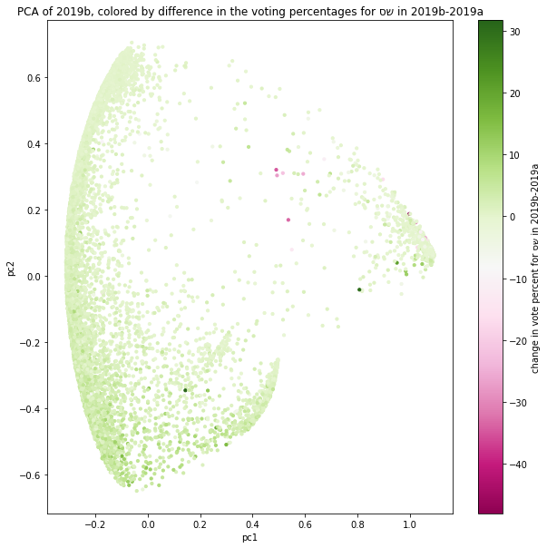

| שם ישוב | סמל ועדה | ברזל | סמל ישוב | קלפי | ריכוז | שופט | בזב 2019b | מצביעים 2019b | פסולים 2019b | כשרים 2019b | אמת 2019b | ג 2019b | ודעם | ז 2019b | זכ | זן | זץ 2019b | טב 2019b | י 2019b | יז 2019b | ינ | יף | יק | כ 2019b | כי | כף | ל 2019b | מחל 2019b | מרצ 2019b | … |
| --- | --- | --- | --- | --- | --- | --- | --- | --- | --- | --- | --- | --- | --- | --- | --- | --- | --- | --- | --- | --- | --- | --- | --- | --- | --- | --- | --- | --- | --- | --- |
| אבטין | 8 | 3366 | 652 | 1.0 | 1 | 0 | 577 | 271 | 4 | 267 | 6 | 0 | 209 | 0 | 0 | 0 | 0 | 0 | 0 | 0 | 0 | 0 | 0 | 0 | 5 | 2 | 0 | 1 | 5 | … |
| אבטין | 8 | 3367 | 652 | 2.0 | 1 | 0 | 569 | 256 | 2 | 254 | 1 | 0 | 215 | 0 | 0 | 0 | 0 | 1 | 0 | 0 | 0 | 0 | 0 | 0 | 3 | 0 | 0 | 0 | 5 | … |
| איבים | 17 | 9050 | 338 | 1.0 | 1 | 0 | 107 | 24 | 0 | 24 | 0 | 0 | 0 | 0 | 0 | 0 | 0 | 3 | 0 | 0 | 0 | 0 | 0 | 0 | 0 | 3 | 1 | 13 | 0 | … |
| אל סייד | 18 | 9828 | 1359 | 2.0 | 1 | 0 | 558 | 205 | 5 | 200 | 3 | 0 | 48 | 0 | 0 | 0 | 0 | 1 | 0 | 0 | 0 | 0 | 0 | 0 | 0 | 0 | 0 | 5 | 13 | … |
| אל סייד | 18 | 9829 | 1359 | 3.0 | 1 | 0 | 592 | 269 | 3 | 266 | 4 | 0 | 64 | 0 | 1 | 0 | 0 | 0 | 0 | 0 | 0 | 2 | 0 | 0 | 2 | 0 | 0 | 7 | 18 | … |
| מעלה עירון | 9 | 4161 | 1327 | 15.0 | 9 | 0 | 607 | 303 | 4 | 299 | 3 | 0 | 267 | 0 | 0 | 0 | 0 | 0 | 0 | 0 | 0 | 0 | 1 | 0 | 4 | 0 | 1 | 0 | 11 | … |
| סייד (שבט) | 18 | 9897 | 1170 | 2.0 | 1 | 0 | 317 | 75 | 1 | 74 | 4 | 0 | 17 | 0 | 0 | 0 | 0 | 1 | 0 | 0 | 0 | 0 | 0 | 0 | 2 | 1 | 0 | 3 | 3 | … |
| סייד (שבט) | 18 | 9898 | 1170 | 3.0 | 1 | 0 | 322 | 64 | 2 | 62 | 1 | 0 | 20 | 0 | 0 | 0 | 0 | 1 | 0 | 0 | 0 | 1 | 0 | 0 | 0 | 0 | 0 | 2 | 1 | … |
| עין חוד | 9 | 3754 | 1320 | 1.0 | 1 | 0 | 193 | 116 | 4 | 112 | 0 | 0 | 107 | 0 | 0 | 0 | 0 | 0 | 0 | 0 | 0 | 0 | 0 | 0 | 0 | 0 | 0 | 0 | 4 | … |
| ראס עלי | 8 | 3398 | 990 | 1.0 | 1 | 1 | 401 | 239 | 2 | 237 | 1 | 0 | 212 | 0 | 0 | 0 | 0 | 0 | 0 | 0 | 0 | 0 | 0 | 0 | 1 | 1 | 0 | 0 | 6 | … |

10 rows × 94 columns

```python
ballot_2019b_2019a = pd.merge(left=df_2019b_kalpi_raw, right=df_2019a_kalpi_raw, how='inner', left_on=['סמל ישוב','קלפי'], right_on=['סמל ישוב','מספר קלפי'], suffixes=(' 2019b', ' 2019a'))
ballot_2019b_2019a.index = ballot_2019b_2019a['שם ישוב']

ballot_2019b_clean = ballot_2019b_2019a.iloc[:,10:42]
ballot_2019a_clean = ballot_2019b_2019a.iloc[:,48:91]
ballot_2019b_2019a['vote_percent_shas_2019b'] = ballot_2019b_2019a['שס 2019b'].div(ballot_2019b_2019a['כשרים 2019b'], axis=0)
ballot_2019b_2019a['vote_percent_shas_2019a'] = ballot_2019b_2019a['שס 2019a'].div(ballot_2019b_2019a['כשרים 2019a'], axis=0)
ballot_2019b_2019a['vote_percent_shas_2019b-2019a'] = ballot_2019b_2019a['vote_percent_shas_2019b'] - ballot_2019b_2019a['vote_percent_shas_2019a']

pca_2019b = ballot_2019b_clean
ballot_2019b_parties_norm_percent= pca_2019b.div(np.sqrt(np.sum((pca_2019b.T)*(pca_2019b.T), axis=0)), axis=0).fillna(0)
pca = PCA(n_components=2)
ballot_2019b_parties_percent_pca = pca.fit_transform(ballot_2019b_parties_norm_percent)
y = ballot_2019b_parties_percent_pca[:,1]
x = ballot_2019b_parties_percent_pca[:,0]

fig, ax = plt.subplots(figsize = (10, 10))
plot = ax.scatter(x ,y , c=100*ballot_2019b_2019a['vote_percent_shas_2019b-2019a'], s=10, label='2019b-2019a', cmap='PiYG')
plt.ylabel('pc2')
plt.xlabel('pc1')
clb = plt.colorbar(plot)
clb.set_label('change in vote percent for סש in 2019b-2019a')
ax.set_title("PCA of 2019b, colored by difference in the voting percentages for סש in 2019b-2019a")
plt.show()

# ballot_2019b_2019a[100*ballot_2019b_2019a['vote_percent_shas_2019b-2019a'] >=15]
ballot_2019b_2019a[100*ballot_2019b_2019a['vote_percent_shas_2019b-2019a'] <= -25]
```

אחוז השינוי בין שתי מערכות הבחירות של 2019 נראה דומה יחסית בגרף. אמנם המפלגה חוותה עליה של מנדט אחד במעבר בין הבחירות אך קשה לזהות את התווספות הקולות לפי קלפיות בגרף זה.

שאלה ו + ז

19a-19b

נבחן את מעבר הקולות בין מפלגת שס לשאר המפלגות בין הבחירות הראשונות של 2019 לבין הבחירות השניות באותה השנה (נבחן רק את השורה הרלוונטית - שס):

• נציין כי נייצג אחוזים הקטנים מ0.5% כ-0% לאור השפעתם הדלה על המסקנות מהנתונים.

• הוספנו עמודת "לא הצביעו" המציינת את אחוז בעלי זכות הבחירה שעברו ממצב של הצבעה למפלגה מסוימת (נבחן את שס) למצב של אי הצבעה כלל.

```
                                 OLS Regression Results
=======================================================================================
Dep. Variable:                     שס   R-squared (uncentered):                   0.978
Model:                            OLS   Adj. R-squared (uncentered):              0.978
Method:                 Least Squares   F-statistic:                          3.618e+04
Date:                Wed, 20 Jan 2021   Prob (F-statistic):                        0.00
Time:                        15:36:12   Log-Likelihood:                         -33789.
No. Observations:                9782   AIC:                                  6.760e+04
Df Residuals:                    9770   BIC:                                  6.769e+04
Df Model:                          12
Covariance Type:            nonrobust
======================================================================================
                         coef    std err          t      P>|t|      [0.025      0.975]
--------------------------------------------------------------------------------------
הליכוד                 0.0512      0.001     35.725      0.000       0.048       0.054
כחול לבן              -0.0127      0.001     -8.733      0.000      -0.016      -0.010
שס                     1.0784      0.003    408.573      0.000       1.073       1.084
יהדות התורה           -0.0033      0.001     -2.356      0.018      -0.006      -0.001
המחנה הדמוקרטי        -0.0227      0.004     -5.201      0.000      -0.031      -0.014
עבודה גשר              0.0106      0.007      1.594      0.111      -0.002       0.024
ישראל ביתנו           -0.0214      0.003     -6.134      0.000      -0.028      -0.015
חד"ש-תע"ל             -0.0087      0.002     -4.390      0.000      -0.013      -0.005
רע"מ-בל"ד             -0.0038      0.002     -1.613      0.107      -0.008       0.001
איחוד מפלגות הימין     0.0102      0.002      4.371      0.000       0.006       0.015
כולנו                  0.0118      0.009      1.350      0.177      -0.005       0.029
לא הצביעו              0.0028      0.001      3.878      0.000       0.001       0.004
==============================================================================
Omnibus:                     5013.591   Durbin-Watson:                   1.621
Prob(Omnibus):                  0.000   Jarque-Bera (JB):           437128.807
Skew:                          -1.564   Prob(JB):                         0.00
Kurtosis:                      35.599   Cond. No.                         31.4
==============================================================================

Warnings:
[1] Standard Errors assume that the covariance matrix of the errors is correctly specified.
```

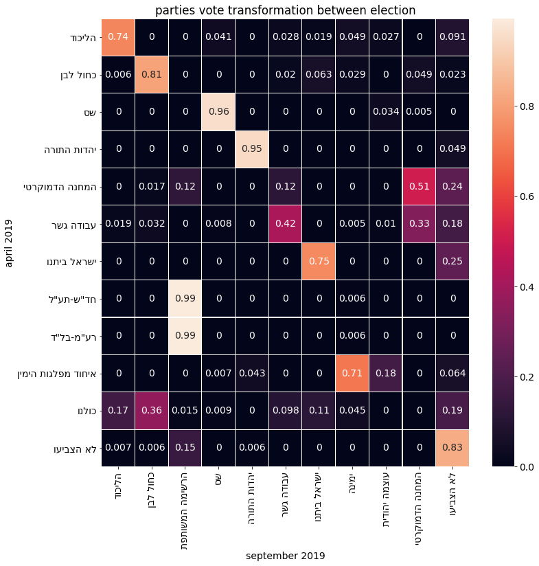

```python
ballot_2019b['שם ישוב'] = ballot_2019b.index
ballot_2019a_2019b = pd.merge(left=ballot_2019a, right=ballot_2019b, how='inner', left_on=['סמל ישוב','מספר קלפי'], right_on=['סמל ישוב','קלפי'], suffixes=(' 2019a', ' 2019b'))
ballot_2019a_2019b.index = ballot_2019a_2019b['שם ישוב']

ballot_2019a_clean = ballot_2019a_2019b.iloc[:,2:13]
ballot_2019b_clean = ballot_2019a_2019b.iloc[:,16:26]


ballot_2019a_clean.columns = ballot_2019a.columns[2:13]
ballot_2019b_clean.columns = ballot_2019b.columns[2:12]

ballot_2019a_clean['לא הצביעו'] = ballot_2019a_2019b['בזב 2019a'] - ballot_2019a_2019b['כשרים 2019a']
ballot_2019b_clean['לא הצביעו'] = ballot_2019a_2019b['בזב 2019b'] - ballot_2019a_2019b['כשרים 2019b']


ballot_2019a_rev_names = [x[::-1] for x in ballot_2019a_clean.columns]
ballot_2019b_rev_names = [x[::-1] for x in ballot_2019b_clean.columns]

M_2019a_2019b = pd.DataFrame(np.dot(np.dot(np.linalg.pinv(np.dot(ballot_2019a_clean.T, ballot_2019a_clean)), ballot_2019a_clean.T), ballot_2019b_clean))
M_2019a_2019b[M_2019a_2019b < 0.005] = 0
M_2019a_2019b_norm = round(M_2019a_2019b.div(M_2019a_2019b.sum(axis=1), axis=0), 3)
M_2019a_2019b_norm.index = ballot_2019a_rev_names
M_2019a_2019b_norm.columns = ballot_2019b_rev_names

fig, ax = plt.subplots(figsize = (12,12))
plt.rcParams.update({'font.size': 14})
plot = sns.heatmap(M_2019a_2019b_norm, linewidths=0.10, annot=True)
plt.ylabel("april 2019")
plt.xlabel("september 2019")
plt.title("parties vote transformation between election")
sm.OLS(ballot_2019b_clean['שס'],ballot_2019a_clean).fit().params.to_dict()
summary = sm.OLS(ballot_2019b_clean['שס'],ballot_2019a_clean)
print(summary.fit().summary())
```

סעיף ו:

נשים לה כי רוב המוחלט של מצביעי שס באפריל 2019 הצביעו לשס גם בספטמבר 2019. מהגרף נראה כי 96% מקולות המפלגה נותרו בתוך המפלגה. בנוסף, 3.4% ממצביעי שס עברו לעוצמה יהודית ובאופן מפתיע 0.51% עברו למפלגת המחנה הדמוקרטי. אם כן, נטען כי אין מעבר קולות סיגניפיקנטי במיוחד בין בחירות אלו שכן רוב המוחלט של הקולות נותר בתוך המפלגה. יחד עם זאת נוכל אולי לסייג את המעבר של 3.4% מהקולות שעברו לעוצמה יהודית (שהתפצלו מאיחוד מפלגות הימין).

סעיף ז:

גם במקרה זה, רוב הקולות המוחלט של שס (כפי שראינו בסעיף הקודם) נשאר בתוך המפלגה ולכן מעבר הקולות לתוך מפלגת שס ממפלגות אחרות מהווה אחוז זניח יחסית. נשים לב כי 0.9% ממצביעי כולנו עברו לשס, 0.77% עברו מהעבודה-גשר לשס, 0.66% מאיחוד מפלגות הימין עברו לשס ו4.1% ממצביעי הליכוד עברו לשס. משום שהליכוד הינה מפלגה גדולה מאוד, 4.1% ממצביעי הליכוד שעברו לשס מהווים כמות גדולה של קולות ולכן נטען שמעבר קולות זה הינו מעבר סיגניפיקנטי לעומת שאר המעברים שהיו זניחים יחסית.

מאחדים את הדטאות 19b-20

```
                                 OLS Regression Results
=======================================================================================
Dep. Variable:                     שס   R-squared (uncentered):                   0.985
Model:                            OLS   Adj. R-squared (uncentered):              0.985
Method:                 Least Squares   F-statistic:                          5.955e+04
Date:                Wed, 20 Jan 2021   Prob (F-statistic):                        0.00
Time:                        15:36:21   Log-Likelihood:                         -31956.
No. Observations:                9690   AIC:                                  6.393e+04
Df Residuals:                    9679   BIC:                                  6.401e+04
Df Model:                          11
Covariance Type:            nonrobust
==================================================================================
                     coef    std err          t      P>|t|      [0.025      0.975]
----------------------------------------------------------------------------------
הליכוד             0.0063      0.001      5.010      0.000       0.004       0.009
כחול לבן           0.0004      0.001      0.316      0.752      -0.002       0.003
הרשימה המשותפת    -0.0056      0.001     -7.816      0.000      -0.007      -0.004
שס                 0.9901      0.002    492.278      0.000       0.986       0.994
יהדות התורה        0.0148      0.001     13.169      0.000       0.013       0.017
עבודה גשר         -0.0109      0.006     -1.821      0.069      -0.023       0.001
ישראל ביתנו       -0.0101      0.003     -3.938      0.000      -0.015      -0.005
ימינה             -0.0147      0.002     -7.003      0.000      -0.019      -0.011
עוצמה יהודית       0.1599      0.008     19.910      0.000       0.144       0.176
המחנה הדמוקרטי    -0.0022      0.004     -0.557      0.578      -0.010       0.006
לא הצביעו          0.0021      0.001      2.901      0.004       0.001       0.004
==============================================================================
Omnibus:                     6813.893   Durbin-Watson:                   1.756
Prob(Omnibus):                  0.000   Jarque-Bera (JB):          1978110.237
Skew:                          -2.276   Prob(JB):                         0.00
Kurtosis:                      72.847   Cond. No.                         33.5
==============================================================================

Warnings:
[1] Standard Errors assume that the covariance matrix of the errors is correctly specified.
```

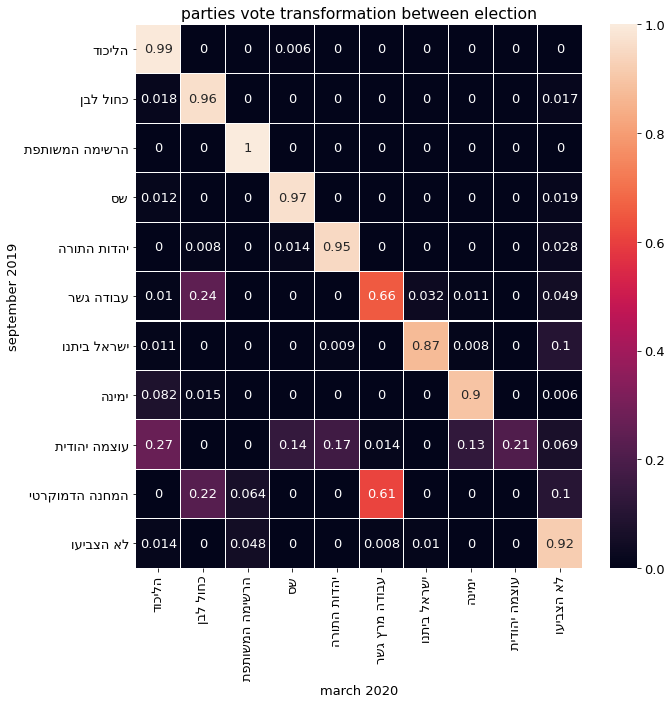

```python
ballot_2019b['שם ישוב'] = ballot_2019b.index
ballot_2019b_2020 = pd.merge(left=ballot_2019b, right=ballot_2020_Otzma_Yehudit, how='inner', left_on=['סמל ישוב','קלפי'], right_on=['סמל ישוב','קלפי'], suffixes=(' 2019b', ' 2020'))
ballot_2019b_2020.index = ballot_2019b_2020['שם ישוב']

ballot_2019b_clean = ballot_2019b_2020.iloc[:,2:12]
ballot_2020_clean = ballot_2019b_2020.iloc[:,15:24]

ballot_2019b_clean.columns = ballot_2019b.columns[2:12]
ballot_2020_clean.columns = ballot_2020_Otzma_Yehudit.columns[2:11]

ballot_2019b_clean['לא הצביעו'] = ballot_2019b_2020['בזב 2019b'] - ballot_2019b_2020['כשרים 2019b']
ballot_2020_clean['לא הצביעו'] = ballot_2019b_2020['בזב 2020'] - ballot_2019b_2020['כשרים 2020']

ballot_2019b_rev_names = [x[::-1] for x in ballot_2019b_clean.columns]
ballot_2020_rev_names = [x[::-1] for x in ballot_2020_clean.columns]

M_2019b_2020 = pd.DataFrame(np.dot(np.dot(np.linalg.pinv(np.dot(ballot_2019b_clean.T, ballot_2019b_clean)), ballot_2019b_clean.T), ballot_2020_clean))
M_2019b_2020[M_2019b_2020 < 0.005] = 0
M_2019b_2020_norm = round(M_2019b_2020.div(M_2019b_2020.sum(axis=1), axis=0), 3)
M_2019b_2020_norm.index = ballot_2019b_rev_names
M_2019b_2020_norm.columns = ballot_2020_rev_names
M_2019b_2020_norm

fig, ax = plt.subplots(figsize = (10,10))
# plt.rcParams.update({'font.size': 14})
# plt.xlabel("2020")
# ax.set_ylabel("2019")
# sns.heatmap(M_2019b_2020_norm, linewidths=0.10, annot=True)

plot = sns.heatmap(M_2019b_2020_norm, linewidths=0.10, annot=True)
plt.rcParams.update({'font.size': 13})
plt.ylabel("september 2019")
plt.xlabel("march 2020")
plt.title("parties vote transformation between election")

sm.OLS(ballot_2020_clean['שס'],ballot_2019b_clean).fit().params.to_dict()
summary = sm.OLS(ballot_2020_clean['שס'],ballot_2019b_clean)
print(summary.fit().summary())
```

סעיף ו:

כעת, נבחן את מעבר הקולות בין מפלגת שס לשאר המפלגות בין הבחירות השניות של 2019 לבין בחירות 2020 (נבחן רק את השורה הרלוונטית - שס): נשים לב כי גם במעבר בין הבחירות הללו, רוב הקולות נותרו בתוך המפלגה (כ- 97%). יתר על כן, 1.2% ממצביעי שס עברו לליכוד, וכ- 1.9% ממצביעי מפלגת שס בבחירות של ספטמבר 2019 החליטו שלא להצביע כלל בבחירות 2020. אם כן, נוכל להסיק כי אין מעברים סיגניפיקנטיים במיוחד במעברים בין הבחירות הללו. מרבית הקולות נותרו בתוך שס ואחוז זניח יחסית של קולות עברו לליכוד או שלא הצביעו כלל.

סעיף ז:

כעת, נבחן את מעבר הקולות בין שאר המפלגות למפלגת שס מהבחירות השניות של 2019 לבחירות 2020 (נבחן רק את העמודה הרלוונטית - שס): נשים לב כי 0.57% מהקולות של הליכוד עברו לשס בנוסף ל- 1.4% ממצביעי יהדות התורה עברו לשס זאת לצד 14% אחוזים ממפלגת עוצמה יהודית שעברו להצביע למפלגת שס. *נציין כי בבחירות לכנסת ה-22 (ספטמבר 2019) מפלגת עוצמה יהודית קיבלה 1.88% מסך הקולות במדינה ואילו בבחירות לכנסת ה-23 עוצמה יהודית קיבלו רק 0.42% מסך האחוז הכללי. ולכן, כמות לא גדולה במיוחד של מצביעים יהוו אחוז גדול ממצביעי מפלגה זו ומשום שהם חוו ירידה משמעותית בין מערכות הבחירות, אחוזים גדולים ממצביעי ההפלגה עברו למפלגות אחרות (ביניהן שס). לא בהכרח מדובר במעבר סיגניפיקנטי משום שמדובר בכמות מצביעים לא גדולה והאחוז שמוצג בטבלה הוא ביחס למפלגה ממנה עוברים הקולות ולא ביחס למלגה אליה מתבצע המעבר.

שאלה ח

אחוז הצבעה בכל קלפי

```python
ballot_2019b_2020
ballot_2019b_2020['אחוז הצבעה 2019b'] = round((ballot_2019b_clean.iloc[:,0:10]).sum(axis=1).div(ballot_2019b_2020['בזב 2019b'], axis=0),3)
ballot_2019b_2020['אחוז הצבעה 2020'] = round((ballot_2020_clean.iloc[:,0:8]).sum(axis=1).div(ballot_2019b_2020['בזב 2020'], axis=0),3)
ballot_2019b_2020['2020-2019b'] = ballot_2019b_2020['אחוז הצבעה 2020'] - ballot_2019b_2020['אחוז הצבעה 2019b']
ballot_2019b_2020['אחוז הקולות ששס קיבלו'] = round((ballot_2019b_2020['שס 2020'].div(ballot_2019b_2020['כשרים 2020'])),3)
(ballot_2019b_2020.iloc[:,26:30]).sort_values('2020-2019b')
```

| שם ישוב | אחוז הצבעה 2019b | אחוז הצבעה 2020 | 2020-2019b | אחוז הקולות ששס קיבלו |
| --- | --- | --- | --- | --- |
| כרמים | 1.090 | 0.772 | -0.318 | 0.000 |
| תלם | 1.028 | 0.751 | -0.277 | 0.024 |
| נווה זוהר | 0.607 | 0.345 | -0.262 | 0.000 |
| יצהר | 0.806 | 0.589 | -0.217 | 0.025 |
| אום אל-פחם | 0.800 | 0.609 | -0.191 | 0.003 |
| ... | ... | ... | ... | ... |
| שדה עוזיהו | 0.294 | 0.792 | 0.498 | 0.149 |
| כסרא-סמיע | 0.057 | 0.612 | 0.555 | 0.003 |
| כסרא-סמיע | 0.091 | 0.674 | 0.583 | 0.000 |
| עראבה | 0.000 | 0.675 | 0.675 | 0.000 |
| שפרעם | 0.000 | 0.681 | 0.681 | 0.002 |

9690 rows × 4 columns

```python
(ballot_2019b_2020.iloc[:,26:30]).sort_values('אחוז הצבעה 2019b')
```

| שם ישוב | אחוז הצבעה 2019b | אחוז הצבעה 2020 | 2020-2019b | אחוז הקולות ששס קיבלו |
| --- | --- | --- | --- | --- |
| שפרעם | 0.000 | 0.681 | 0.681 | 0.002 |
| עראבה | 0.000 | 0.675 | 0.675 | 0.000 |
| כסרא-סמיע | 0.057 | 0.612 | 0.555 | 0.003 |
| ירושלים | 0.060 | 0.085 | 0.025 | 0.000 |
| תראבין א-צאנע (שבט) | 0.065 | 0.090 | 0.025 | 0.000 |
| ... | ... | ... | ... | ... |
| אשדוד | 0.947 | 0.872 | -0.075 | 0.050 |
| חיפה | 0.951 | 0.917 | -0.034 | 0.008 |
| עמיחי | 0.958 | 0.836 | -0.122 | 0.106 |
| תלם | 1.028 | 0.751 | -0.277 | 0.024 |
| כרמים | 1.090 | 0.772 | -0.318 | 0.000 |

9690 rows × 4 columns

```python
(ballot_2019b_2020.iloc[:,26:30]).sort_values('אחוז הצבעה 2020')
```

| שם ישוב | אחוז הצבעה 2019b | אחוז הצבעה 2020 | 2020-2019b | אחוז הקולות ששס קיבלו |
| --- | --- | --- | --- | --- |
| שער מנשה | 0.084 | 0.081 | -0.003 | 0.273 |
| ירושלים | 0.060 | 0.085 | 0.025 | 0.000 |
| תראבין א-צאנע (שבט) | 0.065 | 0.090 | 0.025 | 0.000 |
| ירושלים | 0.156 | 0.095 | -0.061 | 0.432 |
| ירושלים | 0.260 | 0.105 | -0.155 | 0.260 |
| ... | ... | ... | ... | ... |
| אשדוד | 0.877 | 0.913 | 0.036 | 0.029 |
| חיפה | 0.951 | 0.917 | -0.034 | 0.008 |
| כרם יבנה (ישיבה) | 0.885 | 0.917 | 0.032 | 0.056 |
| אשדוד | 0.918 | 0.924 | 0.006 | 0.189 |
| חצור הגלילית | 0.906 | 0.940 | 0.034 | 0.003 |

9690 rows × 4 columns

```python
ballot_2019b_2020['ימין 2019b'] = ballot_2019b_2020['הליכוד 2019b'] + ballot_2019b_2020['יהדות התורה 2019b'] + ballot_2019b_2020['ימינה 2019b'] + ballot_2019b_2020['שס 2019b'] + ballot_2019b_2020['ישראל ביתנו 2019b']
ballot_2019b_2020['שמאל 2019b'] = ballot_2019b_2020['המחנה הדמוקרטי'] + ballot_2019b_2020['הרשימה המשותפת 2019b'] + ballot_2019b_2020['כחול לבן 2019b'] + ballot_2019b_2020['עבודה גשר']
ballot_2019b_2020['אחוז הצבעה לימין 2019b'] = round(ballot_2019b_2020['ימין 2019b'].div(ballot_2019b_2020['ימין 2019b']+ballot_2019b_2020['שמאל 2019b']).fillna(0),3)

ballot_2019b_2020['ימין 2020'] = ballot_2019b_2020['הליכוד 2020'] + ballot_2019b_2020['יהדות התורה 2020'] + ballot_2019b_2020['ימינה 2020'] + ballot_2019b_2020['שס 2020'] + ballot_2019b_2020['ישראל ביתנו 2020']
ballot_2019b_2020['שמאל 2020'] = ballot_2019b_2020['הרשימה המשותפת 2020'] + ballot_2019b_2020['כחול לבן 2020'] + ballot_2019b_2020['עבודה מרץ גשר']
ballot_2019b_2020['אחוז הצבעה לימין 2020'] = round(ballot_2019b_2020['ימין 2020'].div(ballot_2019b_2020['ימין 2020']+ballot_2019b_2020['שמאל 2020']),3)
ballot_2019b_2020['אחוז ההצבעה לימין ב2019b פחות אחוז ההצבעה לימין 2020'] = ballot_2019b_2020['אחוז הצבעה לימין 2019b'] - ballot_2019b_2020['אחוז הצבעה לימין 2020']
(ballot_2019b_2020.iloc[:,29:]).sort_values('אחוז ההצבעה לימין ב2019b פחות אחוז ההצבעה לימין 2020')
# ballot_2019b_2020.sort_values('אחוז ההצבעה לימין ב2019b פחות אחוז ההצבעה לימין 2020')
```

| שם ישוב | אחוז הקולות ששס קיבלו | ימין 2019b | שמאל 2019b | אחוז הצבעה לימין 2019b | ימין 2020 | שמאל 2020 | אחוז הצבעה לימין 2020 | אחוז ההצבעה לימין ב2019b פחות אחוז ההצבעה לימין 2020 |
| --- | --- | --- | --- | --- | --- | --- | --- | --- |
| כסרא-סמיע | 0.003 | 11 | 25 | 0.306 | 334 | 60 | 0.848 | -0.542 |
| כסרא-סמיע | 0.000 | 17 | 41 | 0.293 | 344 | 87 | 0.798 | -0.505 |
| ראשון לציון | 0.039 | 195 | 289 | 0.403 | 354 | 131 | 0.730 | -0.327 |
| כסרא-סמיע | 0.000 | 42 | 85 | 0.331 | 212 | 150 | 0.586 | -0.255 |
| ראשון לציון | 0.102 | 171 | 116 | 0.596 | 266 | 47 | 0.850 | -0.254 |
| ... | ... | ... | ... | ... | ... | ... | ... | ... |
| עכו | 0.047 | 206 | 104 | 0.665 | 168 | 172 | 0.494 | 0.171 |
| מג'דל שמס | 0.000 | 32 | 46 | 0.410 | 17 | 57 | 0.230 | 0.180 |
| דייר אל-אסד | 0.108 | 153 | 366 | 0.295 | 57 | 442 | 0.114 | 0.181 |
| מסעדה | 0.026 | 32 | 45 | 0.416 | 17 | 61 | 0.218 | 0.198 |
| ע'ג'ר | 0.272 | 167 | 42 | 0.799 | 140 | 119 | 0.541 | 0.258 |

9690 rows × 8 columns

בשאלה זו נתבקשנו למצוא קלפיות חשודות. נחפש את הקלפיות בהן היו אחוזי הצבעה גדולים מהרגיל ביחס לשאר הקלפיות בבחירות לכנסת ה-22 ובבחירות הכנסת ה-23.

בנוסף, נבצע בדיקה של השינוי באחוזי ההצבעה בין הבחירות הללו.

לבסוף, נציין את ההשפעה של קלפיות חשודות אלו על מפלגת שס.

ניתן לראות שיש קלפיות שבבחירות השניות של 2019 היו 0% הצבעה, ההסבר לכך הוא (לאחר בדיקה באתר הבחירות לכנסת) שאלו הן קלפיות פסולות.

ניתן לראות שבבחירות ספטמבר 2019 יש 2 קלפיות (תלם וכרמים) שאחוז ההצבעה שלהם גדול מ100%. כלומר, יש יותר קולות כשרים מבעלי זכות בחירה, מצב שלא אמור לקרות.

קלפי חשודה נוספת היא אחת מהקלפיות בכסרא-סמיע שהשינוי באחוזי ההצבעה שלה הוא הגדול ביותר מבין כלל הקלפיות שלא נפסלו. אחוז ההצבעה בקלפי זו עלה מ-9.1% הצבעה ל67.44% הצבעה, מבדיקה מעמיקה יותר מול אתר הבחירות נוכחנו לראות שהדבר נובע בעיקר בשינוי דרסטי במצביעי הליכוד בין בחירות אלו. בבחירות לכנסת ה-22 אחוזי ההצבעה לליכוד בקלפי זו היו 3.45% (2 אנשים) ואילו בבחירות ב2020 אחוז ההצבעה לליכוד עמד על כ- 75.58% (328 מצביעים). בנוסף, ביצענו חלוקה של גושים על מנת לבדוק מעבר חריג בין גוש השמאל לימין ולהיפך. גוש הימין שהגדרנו כלל את המפלגות הבאות : ימינה, הליכוד, שס, יהדות התורה וישראל ביתנו. שאר המפלגות נכללו תחת גוש השמאל. נשים לב (בטבלה האחרונה), לשינוי באחוזי ההצבעה בין הגושים בקלפיות החריגות בישובים השונים. מלבד הקלפיות החריגות בכסרא סמיע עליהן פירטנו בפסקה הקודמת. נשים לב לשתי קלפיות בראשון לציון, שם היה מעבר בין גושים שעמד על ירידה של 32.7 ו25.4 אחוזי הצבעה לגוש השמאל בין מערכות הבחירות השונות. מנגד, מצביעי קלפיות בעג'ר ומסעדה למשל, שינו את דפוסי ההצבעה שלהם. בקלפי במסעדה, חל גידול של כ-19.8 באחוזי ההצבעה לגוש השמאל. זאת ועוד, קלפי בע'ג'ר חוותה גידול באחוזי ההצבעה לגוש השמאל של כ-25.8. מדובר בקלפיות חשודות שכן מדובר בשינוי מהותי יחסית בדפוס ההצבעה.

```python
%%shell
jupyter nbconvert --to html /final_project_204589949_208848317.ipynb
```

```
[NbConvertApp] Converting notebook /final_project_204589949_208848317.ipynb to html
[NbConvertApp] Writing 1470566 bytes to /final_project_204589949_208848317.html
```